# Coding Assignment 1

Group 6

Due: 2024-09-22 23:59

```r
library(readr)
library(corrplot)
library(car)
```

A Florida health insurance company wants to predict annual claims for individual clients. The company pulls a random sample of 100 customers. The owner wishes to charge an actuarially fair premium to ensure a normal rate of return. The owner collects all of their current customer’s health care expenses from the last year and compares them with what is known about each customer’s plan.

The data on the 100 customers in the sample is as follows:

- Charges: Total medical expenses for a particular insurance plan (in dollars)
- Age: Age of the primary beneficiary
- BMI: Primary beneficiary’s body mass index (kg/m2)
- Female: Primary beneficiary’s birth sex (0 = Male, 1 = Female)
- Children: Number of children covered by health insurance plan (includes other dependents as well)
- Smoker: Indicator if primary beneficiary is a smoker (0 = non-smoker, 1 = smoker)
- Cities: Dummy variables for each city with the default being Sanford

Answer the following questions using complete sentences and attach all output, plots, etc. within this report.

**For this assignment, ignore the categorical variables (gender, smoker, cities)**

# Question 1

Perform univariate analyses on the quantitative variables (center, shape, spread). Include descriptive statistics, and histograms. Be sure to use terms discussed in class such as bimodal, skewed left, etc.

```r
##Modes

getModes <- function(x) {
ux <- unique(x)
tab <- tabulate(match(x, ux))
ux[tab == max(tab)]
}

getModes(InsuranceData$Age)
```

```
## [1] 19 18
```

```r
getModes(InsuranceData$BMI)
```

```
## [1] 30.210 34.105 26.315 33.820 34.100 33.330 31.160
```

```r
getModes(InsuranceData$Children)
```

```
## [1] 0
```

```r
#Spread

sd(InsuranceData$Age)
```

```
## [1] 14.6423
```

```r
sd(InsuranceData$BMI)
```

```
## [1] 5.971824
```

```r
sd(InsuranceData$Children)
```

```
## [1] 1.230053
```

```r
#Center
summary(InsuranceData$Age)
```

```
##    Min. 1st Qu.  Median    Mean 3rd Qu.    Max.
##   18.00   25.75   38.00   39.13   52.00   64.00
```

```r
summary(InsuranceData$BMI)
```

```
##    Min. 1st Qu.  Median    Mean 3rd Qu.    Max.
##   17.77   27.18   31.47   31.54   35.23   46.70
```

```r
summary(InsuranceData$Children)
```

```
##    Min. 1st Qu.  Median    Mean 3rd Qu.    Max.
##    0.00    0.00    1.00    1.11    2.00    5.00
```

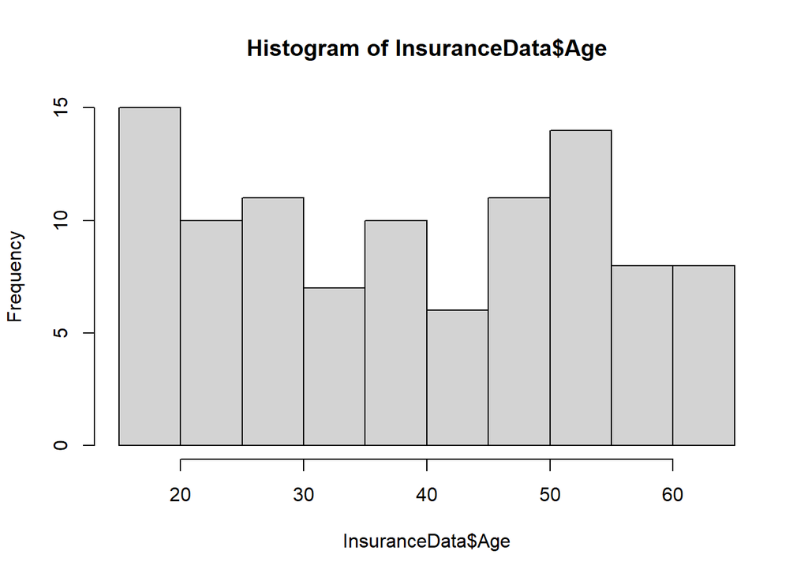

```r
#Shape

hist(InsuranceData$Age)
```

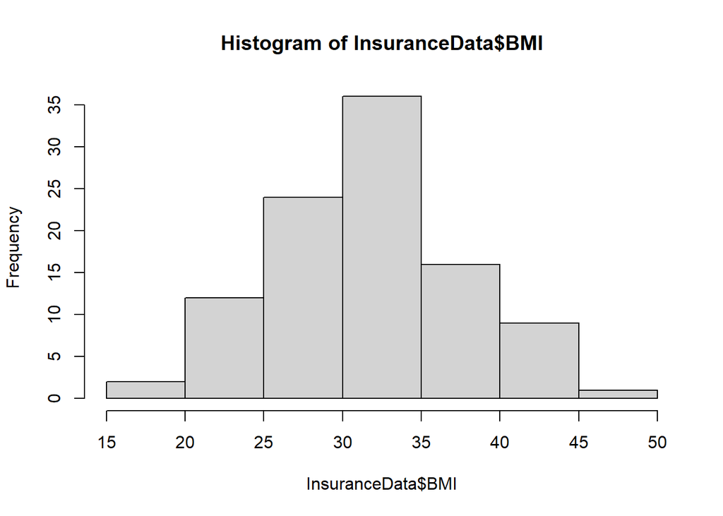

```r
hist(InsuranceData$BMI)
```

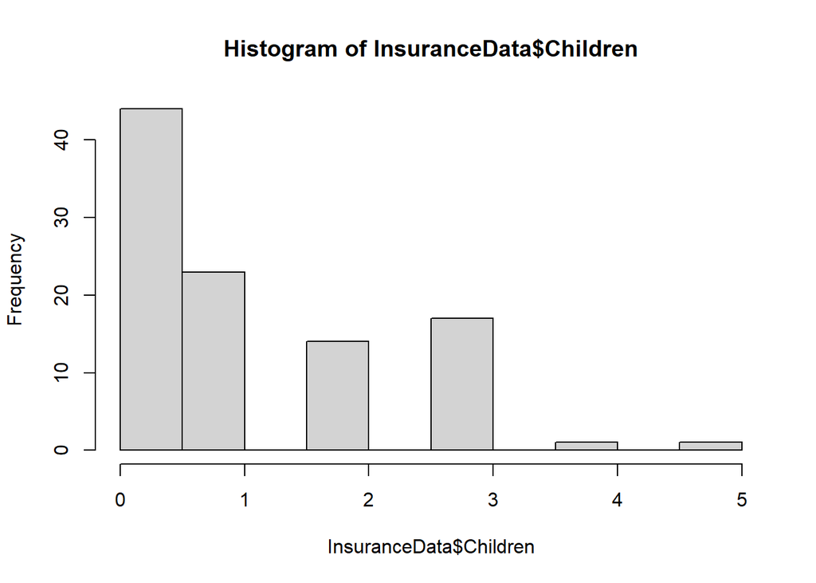

```r
hist(InsuranceData$Children)
```

### **Uni-variate Analysis:**

# Question 2

Perform bivariate analyses on the quantitative variables (direction, strength and form). Describe the linear association between all variables.

```r
cor(InsuranceData[c("Charges","Age", "BMI", "Children")])
```

```
##             Charges        Age        BMI   Children
## Charges  1.00000000 0.21068882 0.28541865 0.02402329
## Age      0.21068882 1.00000000 0.01630997 0.10351247
## BMI      0.28541865 0.01630997 1.00000000 0.04254433
## Children 0.02402329 0.10351247 0.04254433 1.00000000
```

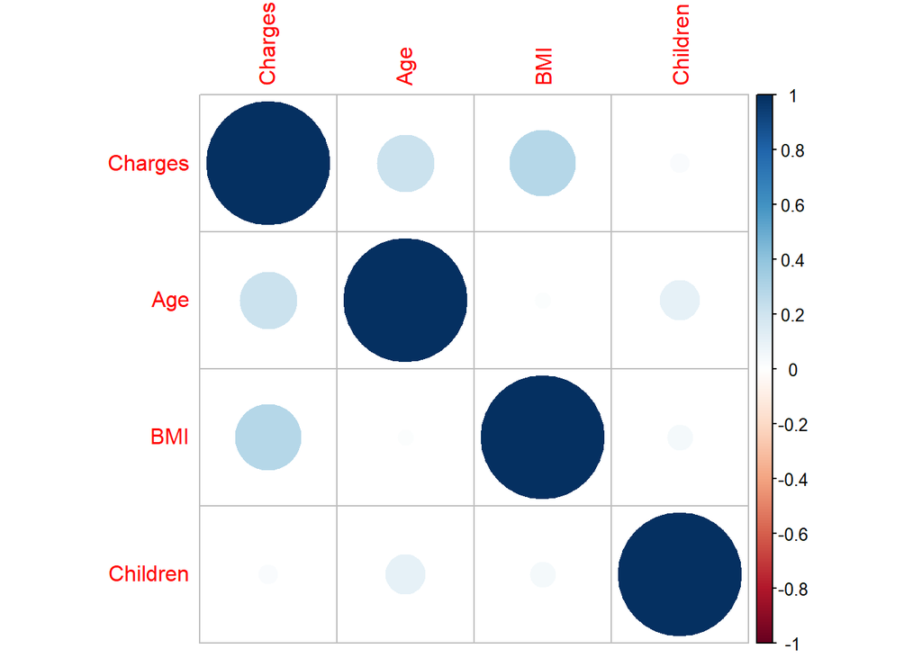

```r
corrplot(cor(InsuranceData[c("Charges","Age", "BMI", "Children")]))
```

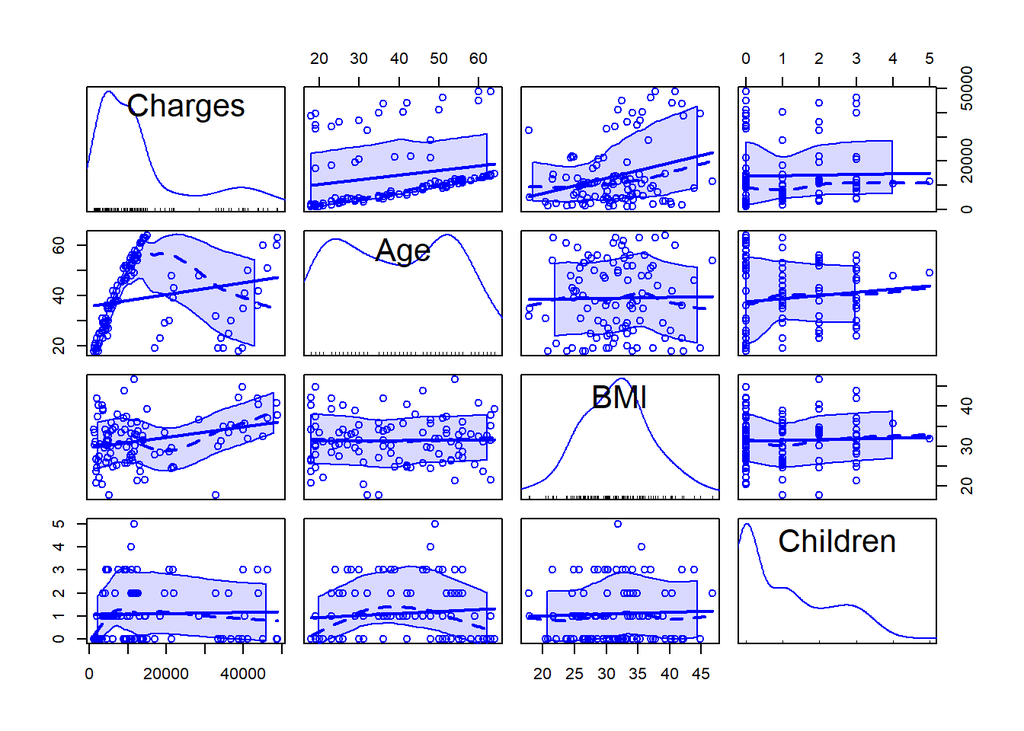

```r
scatterplotMatrix(InsuranceData[c("Charges","Age", "BMI", "Children")])
```

### **Bi-variate Analysis:**

# Question 3

#Generate a regression equation in the following form:

$$Charges =
\beta_{0}+\beta_{1}*Age+\beta_{2}*BMI+\beta_{3}*Children$$

```r
model <- lm(Charges ~ Age + BMI + Children, data = InsuranceData)

summary(model)
```

```
##
## Call:
## lm(formula = Charges ~ Age + BMI + Children, data = InsuranceData)
##
## Residuals:
##    Min     1Q Median     3Q    Max
## -15876  -8290  -4670   6261  28642
##
## Coefficients:
##              Estimate Std. Error t value Pr(>|t|)
## (Intercept) -12798.79    7552.46  -1.695  0.09338 .
## Age            186.99      86.74   2.156  0.03360 *
## BMI            625.41     211.72   2.954  0.00395 **
## Children      -101.33    1033.32  -0.098  0.92209
## ---
## Signif. codes:  0 '***' 0.001 '**' 0.01 '*' 0.05 '.' 0.1 ' ' 1
##
## Residual standard error: 12570 on 96 degrees of freedom
## Multiple R-squared:  0.124,  Adjusted R-squared:  0.09664
## F-statistic:  4.53 on 3 and 96 DF,  p-value: 0.005147
```

also write out the regression cleanly in this document.

**The regression equation written clearly: Charges = -12798.79 + 186.99(Age) + 625.41(BMI) - 101.33(Children)**

# Question 4

An eager insurance representative comes back with a potential client. The client is 40, their BMI is 30, and they have one dependent. Using the regression equation above, predict the amount of medical expenses associated with this policy. (Provide a 95% confidence interval as well)

```r
newPrediction <- data.frame(Age = 40,
                         BMI = 30,
                         Children = 1)

predict(model ,newdata = newPrediction, interval = "confidence", level = 0.95)
```

```
##        fit      lwr      upr
## 1 13341.85 10750.64 15933.06
```